# Codebook

```r
knitr::opts_chunk$set(
  warning = FALSE, # ocultamos warnings para un reporte final más limpio
  message = FALSE, # ocultamos mensajes (ej. carga de librerías)
  error = TRUE, # do not interrupt codebook generation in case of errors,
                # usually better for debugging
  echo = TRUE  # show R code
)
ggplot2::theme_set(ggplot2::theme_bw())
```

```r
library(codebook)
library(arrow)
library(here)

# Cargamos nuestra base de datos documentada, generada en el script 07_Documentar.R
codebook_data <- read_parquet(here("datos", "procesados", "base_codebook_110726.parquet"))

# Omitimos detect_missing() y detect_scales(): nuestros valores perdidos ya
# fueron tratados en el script 02_Acondicionar.R, y nuestras variables no
# siguen el patrón de nombres de escalas (scale_1, scale_2R, ...) que
# detect_scales() necesita para reconocer agregados.
```

creacion codebook

```r
# omit metadata_json (uses HTML) to avoid an error when knitting to PDF;
# metadata_table and other components are automatically
# rendered as static tables for PDF output
codebook(codebook_data)
```

### Metadata

#### Description

**Dataset name**: Base de Datos Analítica - Inseguridad Alimentaria ENAHO 2025

Submuestra de la Encuesta Nacional de Hogares (2025) restringida a personas con nivel educativo declarado y cuyo hogar respondió el módulo de Inseguridad Alimentaria (módulo 130).

**Metadata for search engines**

- **Date published**: 2026-07-12
- **Creator**:

| name | value |
| --- | --- |
| 1 | Micaela Cusipuma |

| name | value |
| --- | --- |
| keywords | edad, sexo, nivel_edu_etiqueta, matricula_anterior_etiqueta, ia_preocupacion_etiqueta, ia_no_saludable_etiqueta, ia_no_variado_etiqueta, ia_saltó_comida_etiqueta, ia_comió_menos_etiqueta, ia_sin_alime… |

## Variables

### edad

Edad del encuestado, en años cumplidos (Fuente: P208A)

#### Distribution

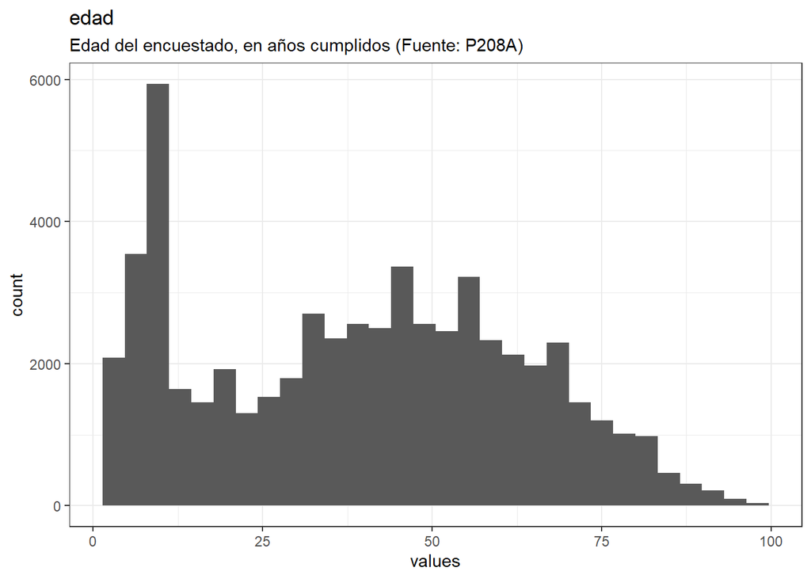

Distribution of values for edad

0 missing values.

#### Summary statistics

| name | label | data_type | n_missing | complete_rate | min | median | max | mean | sd | hist |
| --- | --- | --- | --- | --- | --- | --- | --- | --- | --- | --- |
| edad | Edad del encuestado, en años cumplidos (Fuente: P208A) | numeric | 0 | 1 | 3 | 40 | 98 | 39.3348 | 23.39318 | ▇▆▇▅▁ |

### sexo

Sexo del encuestado (Fuente: P207)

#### Distribution

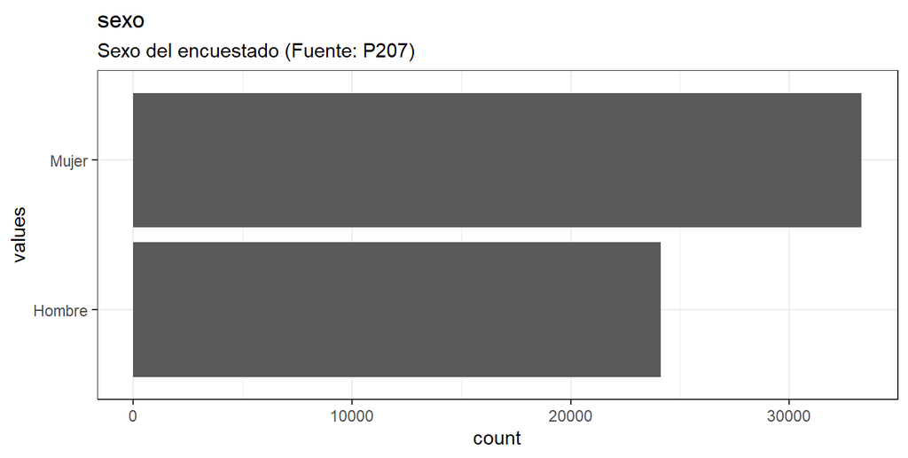

Distribution of values for sexo

0 missing values.

#### Summary statistics

| name | label | data_type | ordered | value_labels | n_missing | complete_rate | n_unique | top_counts |
| --- | --- | --- | --- | --- | --- | --- | --- | --- |
| sexo | Sexo del encuestado (Fuente: P207) | factor | FALSE | 1. Hombre, 2. Mujer | 0 | 1 | 2 | Muj: 33302, Hom: 24120 |

### nivel_edu_etiqueta

Nivel educativo alcanzado, 12 categorías originales (Fuente: P301A)

#### Distribution

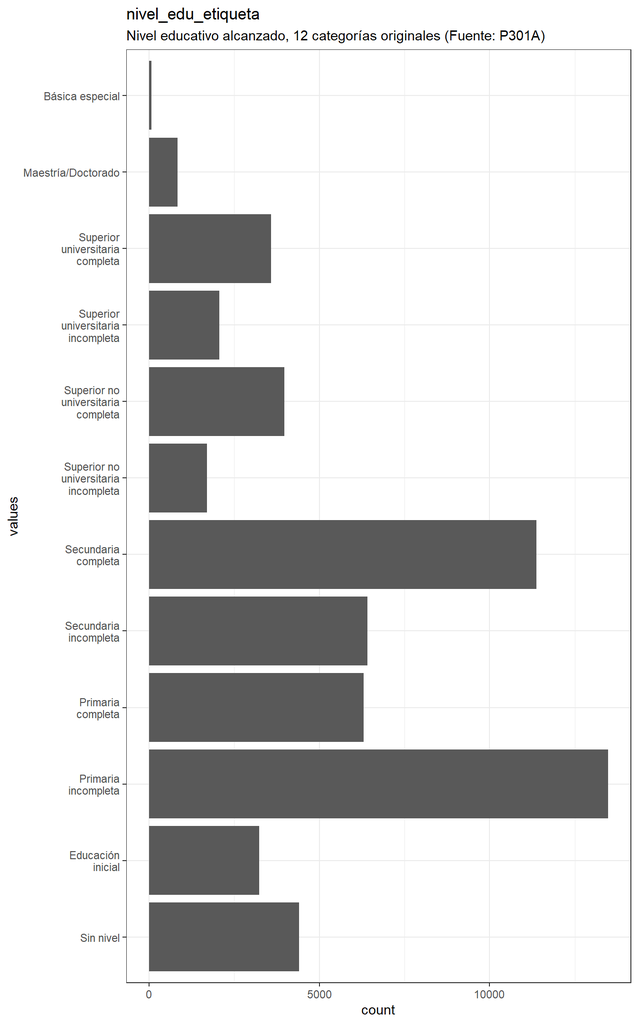

Distribution of values for nivel_edu_etiqueta

0 missing values.

#### Summary statistics

| name | label | data_type | ordered | value_labels | n_missing | complete_rate | n_unique | top_counts | description |
| --- | --- | --- | --- | --- | --- | --- | --- | --- | --- |
| nivel_edu_etiqueta | Nivel educativo alcanzado, 12 categorías originales (Fuente: P301A) | factor | FALSE | 1. Sin nivel, 2. Educación inicial, 3. Primaria incompleta, 4. Primaria completa, 5. Secundaria incompleta, 6. Secundaria completa, 7. Superior no universitaria incompleta, 8. Superior no universitari… | 0 | 1 | 12 | Pri: 13471, Sec: 11373, Sec: 6409, Pri: 6297 | Se eliminaron los casos con código 99 (No especificado, MCAR) antes de exportar la base acondicionada (script 02). |

### matricula_anterior_etiqueta

¿Estuvo matriculado en algún centro o programa educativo el año pasado? (Fuente: P303)

#### Distribution

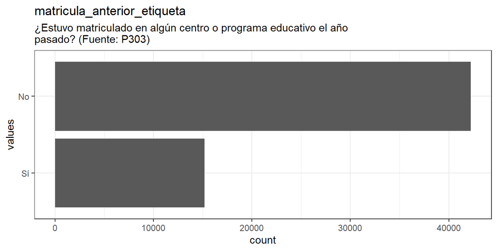

Distribution of values for matricula_anterior_etiqueta

0 missing values.

#### Summary statistics

| name | label | data_type | ordered | value_labels | n_missing | complete_rate | n_unique | top_counts |
| --- | --- | --- | --- | --- | --- | --- | --- | --- |
| matricula_anterior_etiqueta | ¿Estuvo matriculado en algún centro o programa educativo el año pasado? (Fuente: P303) | factor | FALSE | 1. Sí, 2. No | 0 | 1 | 2 | No: 42220, Sí: 15202 |

### ia_preocupacion_etiqueta

Preocupación por falta de comida en el hogar (Fuente: P130_1)

#### Distribution

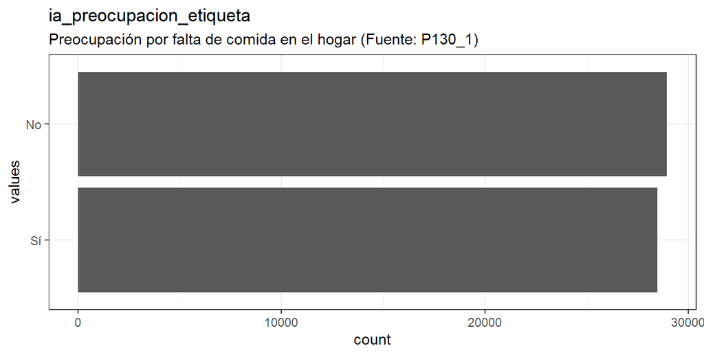

Distribution of values for ia_preocupacion_etiqueta

0 missing values.

#### Summary statistics

| name | label | data_type | ordered | value_labels | n_missing | complete_rate | n_unique | top_counts | description |
| --- | --- | --- | --- | --- | --- | --- | --- | --- | --- |
| ia_preocupacion_etiqueta | Preocupación por falta de comida en el hogar (Fuente: P130_1) | factor | FALSE | 1. Sí, 2. No | 0 | 1 | 2 | No: 28938, Sí: 28484 | Las 8 preguntas FIES presentan NA estructural (45% de los casos, hogares donde no se aplicó el módulo 130 ese mes); estos casos se eliminaron. Las respuestas ‘No sabe’/‘No responde’ se recodificaron c… |

### ia_no_saludable_etiqueta

No comió alimentos saludables/nutritivos (Fuente: P130_2)

#### Distribution

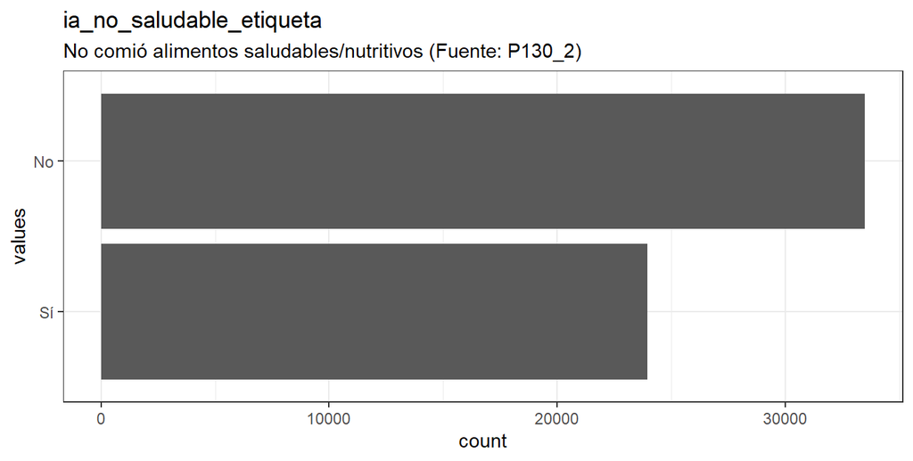

Distribution of values for ia_no_saludable_etiqueta

0 missing values.

#### Summary statistics

| name | label | data_type | ordered | value_labels | n_missing | complete_rate | n_unique | top_counts |
| --- | --- | --- | --- | --- | --- | --- | --- | --- |
| ia_no_saludable_etiqueta | No comió alimentos saludables/nutritivos (Fuente: P130_2) | factor | FALSE | 1. Sí, 2. No | 0 | 1 | 2 | No: 33479, Sí: 23943 |

### ia_no_variado_etiqueta

No comió alimentos variados (Fuente: P130_3)

#### Distribution

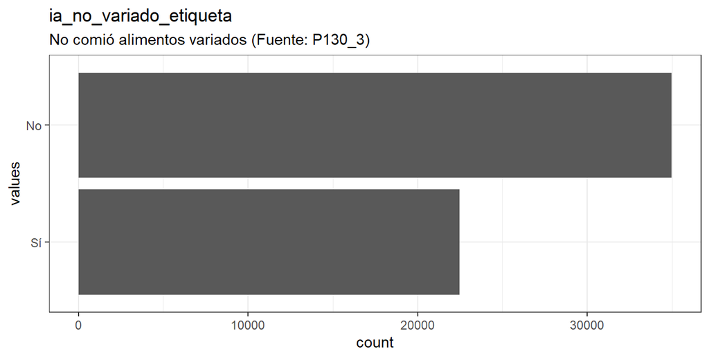

Distribution of values for ia_no_variado_etiqueta

0 missing values.

#### Summary statistics

| name | label | data_type | ordered | value_labels | n_missing | complete_rate | n_unique | top_counts |
| --- | --- | --- | --- | --- | --- | --- | --- | --- |
| ia_no_variado_etiqueta | No comió alimentos variados (Fuente: P130_3) | factor | FALSE | 1. Sí, 2. No | 0 | 1 | 2 | No: 34967, Sí: 22455 |

### ia_saltó_comida_etiqueta

Dejó de desayunar, almorzar o cenar (Fuente: P130_4)

#### Distribution

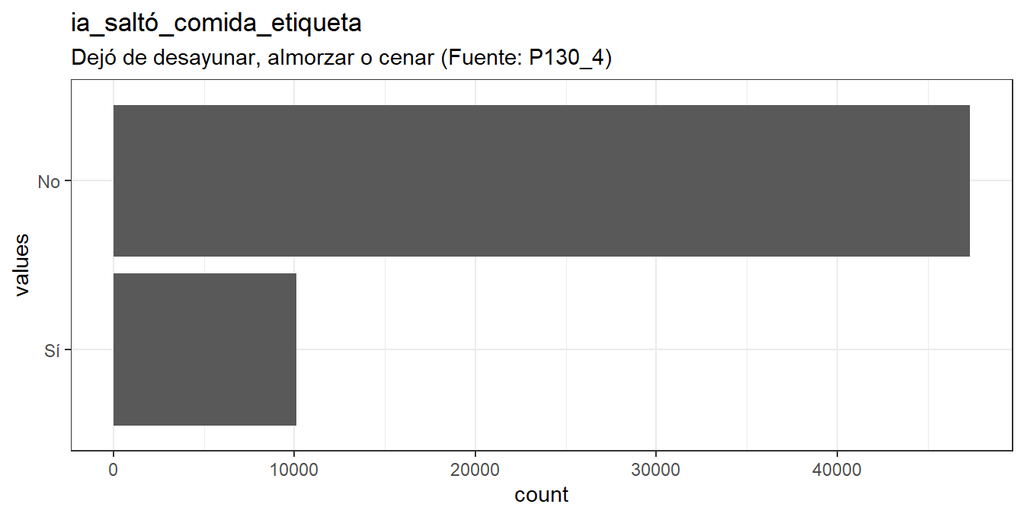

Distribution of values for ia_saltó_comida_etiqueta

0 missing values.

#### Summary statistics

| name | label | data_type | ordered | value_labels | n_missing | complete_rate | n_unique | top_counts |
| --- | --- | --- | --- | --- | --- | --- | --- | --- |
| ia_saltó_comida_etiqueta | Dejó de desayunar, almorzar o cenar (Fuente: P130_4) | factor | FALSE | 1. Sí, 2. No | 0 | 1 | 2 | No: 47318, Sí: 10104 |

### ia_comió_menos_etiqueta

Comió menor cantidad de lo normal (Fuente: P130_5)

#### Distribution

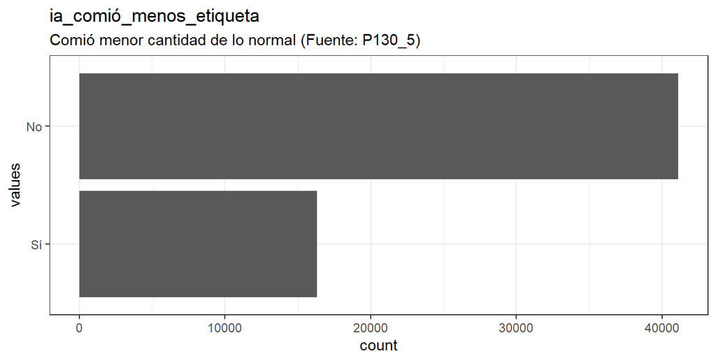

Distribution of values for ia_comió_menos_etiqueta

0 missing values.

#### Summary statistics

| name | label | data_type | ordered | value_labels | n_missing | complete_rate | n_unique | top_counts |
| --- | --- | --- | --- | --- | --- | --- | --- | --- |
| ia_comió_menos_etiqueta | Comió menor cantidad de lo normal (Fuente: P130_5) | factor | FALSE | 1. Sí, 2. No | 0 | 1 | 2 | No: 41101, Sí: 16321 |

### ia_sin_alimentos_etiqueta

El hogar se quedó sin alimentos (Fuente: P130_6)

#### Distribution

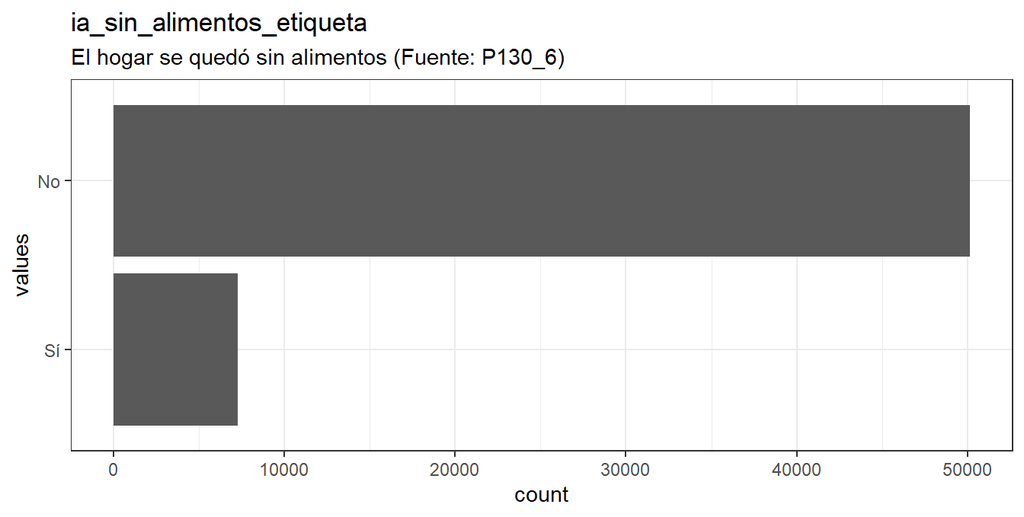

Distribution of values for ia_sin_alimentos_etiqueta

0 missing values.

#### Summary statistics

| name | label | data_type | ordered | value_labels | n_missing | complete_rate | n_unique | top_counts |
| --- | --- | --- | --- | --- | --- | --- | --- | --- |
| ia_sin_alimentos_etiqueta | El hogar se quedó sin alimentos (Fuente: P130_6) | factor | FALSE | 1. Sí, 2. No | 0 | 1 | 2 | No: 50122, Sí: 7300 |

### ia_hambre_etiqueta

Tuvo hambre pero no comió (Fuente: P130_7)

#### Distribution

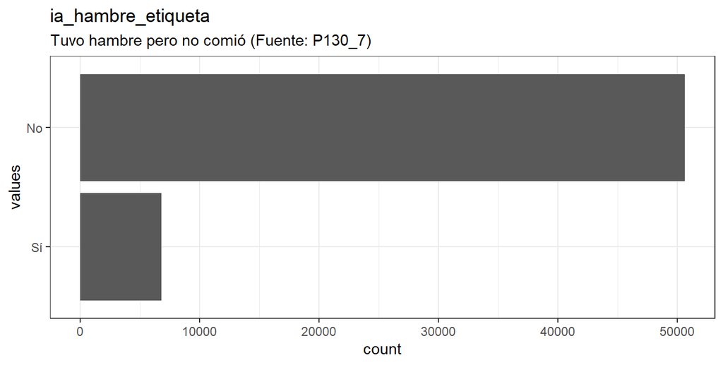

Distribution of values for ia_hambre_etiqueta

0 missing values.

#### Summary statistics

| name | label | data_type | ordered | value_labels | n_missing | complete_rate | n_unique | top_counts |
| --- | --- | --- | --- | --- | --- | --- | --- | --- |
| ia_hambre_etiqueta | Tuvo hambre pero no comió (Fuente: P130_7) | factor | FALSE | 1. Sí, 2. No | 0 | 1 | 2 | No: 50597, Sí: 6825 |

### ia_dia_sin_comer_etiqueta

Estuvo sin comer un día entero (Fuente: P130_8)

#### Distribution

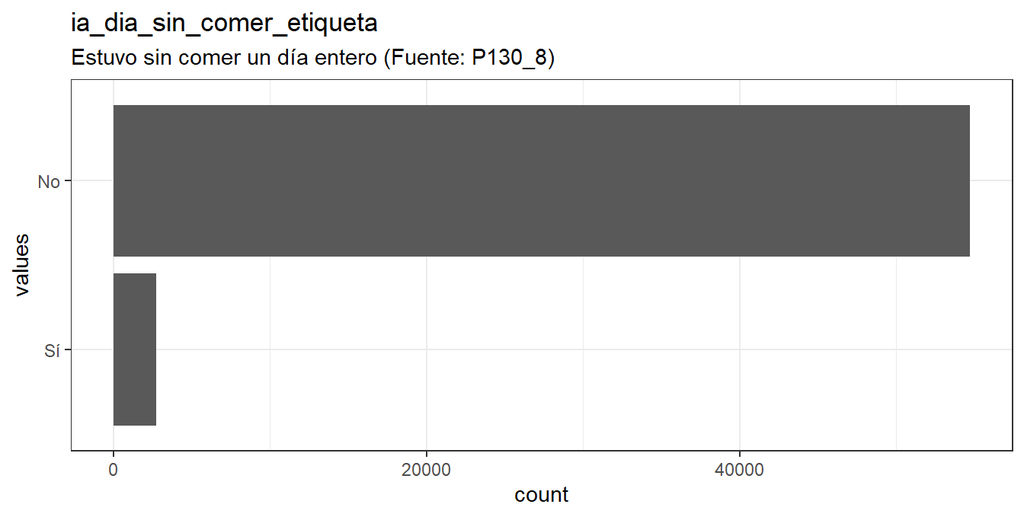

Distribution of values for ia_dia_sin_comer_etiqueta

0 missing values.

#### Summary statistics

| name | label | data_type | ordered | value_labels | n_missing | complete_rate | n_unique | top_counts |
| --- | --- | --- | --- | --- | --- | --- | --- | --- |
| ia_dia_sin_comer_etiqueta | Estuvo sin comer un día entero (Fuente: P130_8) | factor | FALSE | 1. Sí, 2. No | 0 | 1 | 2 | No: 54680, Sí: 2742 |

### score_fies_bruto

Puntaje bruto FIES: N° de respuestas afirmativas (0 a 8)

#### Distribution

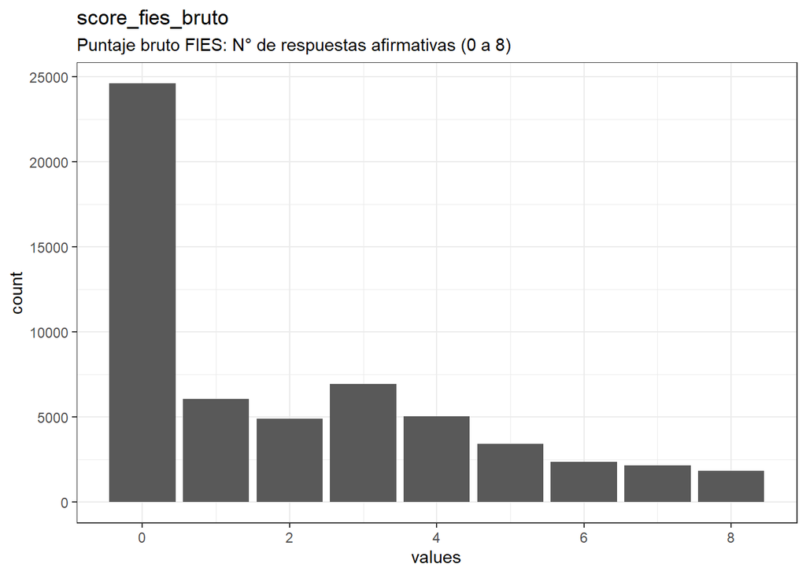

Distribution of values for score_fies_bruto

0 missing values.

#### Summary statistics

| name | label | data_type | n_missing | complete_rate | min | median | max | mean | sd | hist | description |
| --- | --- | --- | --- | --- | --- | --- | --- | --- | --- | --- | --- |
| score_fies_bruto | Puntaje bruto FIES: N° de respuestas afirmativas (0 a 8) | numeric | 0 | 1 | 0 | 1 | 8 | 2.057992 | 2.362445 | ▇▃▁▂▁ | Suma simple de respuestas afirmativas (‘Sí’=1) a las 8 preguntas de la escala FIES (rango 0 a 8). |

### severidad_rasch

Severidad latente estimada por el modelo Rasch ponderado (RM.weights)

#### Distribution

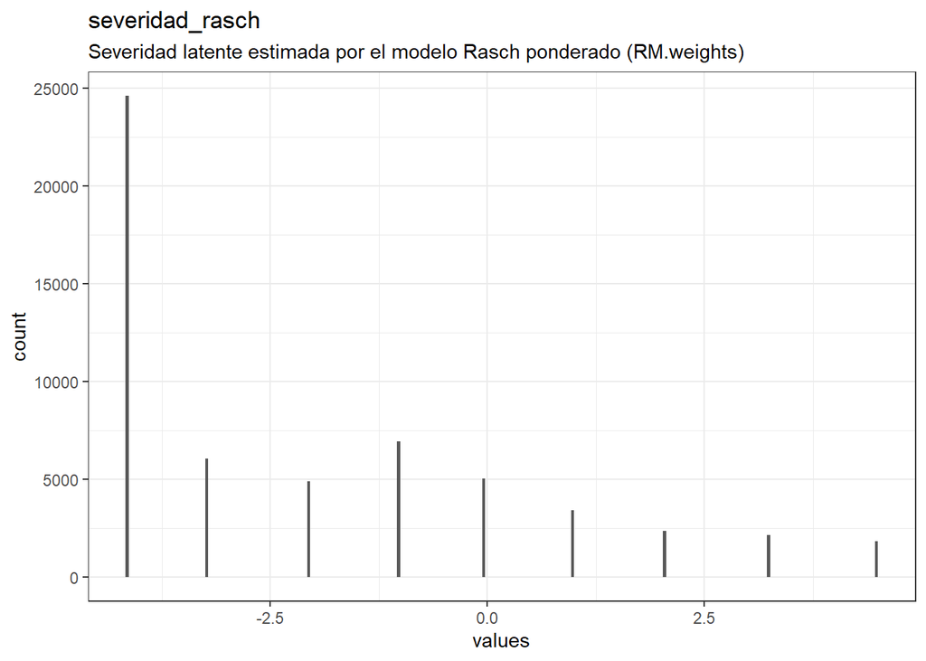

Distribution of values for severidad_rasch

0 missing values.

#### Summary statistics

| name | label | data_type | n_missing | complete_rate | min | median | max | mean | sd | hist | description |
| --- | --- | --- | --- | --- | --- | --- | --- | --- | --- | --- | --- |
| severidad_rasch | Severidad latente estimada por el modelo Rasch ponderado (RM.weights) | numeric | 0 | 1 | -4.1 | -3.2 | 4.5 | -2.015395 | 2.485533 | ▇▃▂▁▁ | Estimado mediante un modelo Rasch ponderado (paquete RM.weights, metodología FIES/Voices of the Hungry de la FAO). El modelo genera un valor por cada puntaje bruto posible (0 a 8, 9 valores), asignado… |

### nivel_inseguridad_alimentaria

Nivel de inseguridad alimentaria (4 categorías, según puntos de corte FIES)

#### Distribution

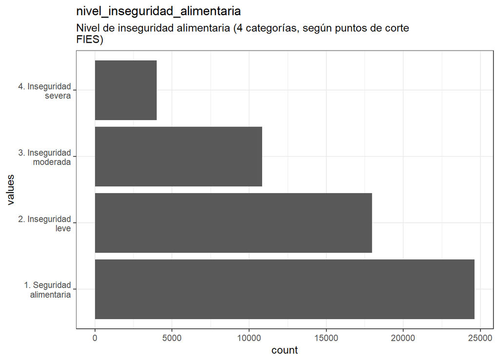

Distribution of values for nivel_inseguridad_alimentaria

0 missing values.

#### Summary statistics

| name | label | data_type | ordered | value_labels | n_missing | complete_rate | n_unique | top_counts | description |
| --- | --- | --- | --- | --- | --- | --- | --- | --- | --- |
| nivel_inseguridad_alimentaria | Nivel de inseguridad alimentaria (4 categorías, según puntos de corte FIES) | factor | FALSE | 1. 1. Seguridad alimentaria, 2. 2. Inseguridad leve, 3. 3. Inseguridad moderada, 4. 4. Inseguridad severa | 0 | 1 | 4 | 1. : 24615, 2. : 17970, 3. : 10833, 4. : 4004 | Clasificación en 4 niveles usando los puntos de corte estándar (4 y 7) para escalas FIES de 8 ítems: 0 respuestas=‘Seguridad alimentaria’, 1-3=‘Inseguridad leve’, 4-6=‘Inseguridad moderada’, 7-8=‘Inse… |

### grupo_edad_teoria

Grupo etario según criterio teórico (etapas de ciclo de vida)

#### Distribution

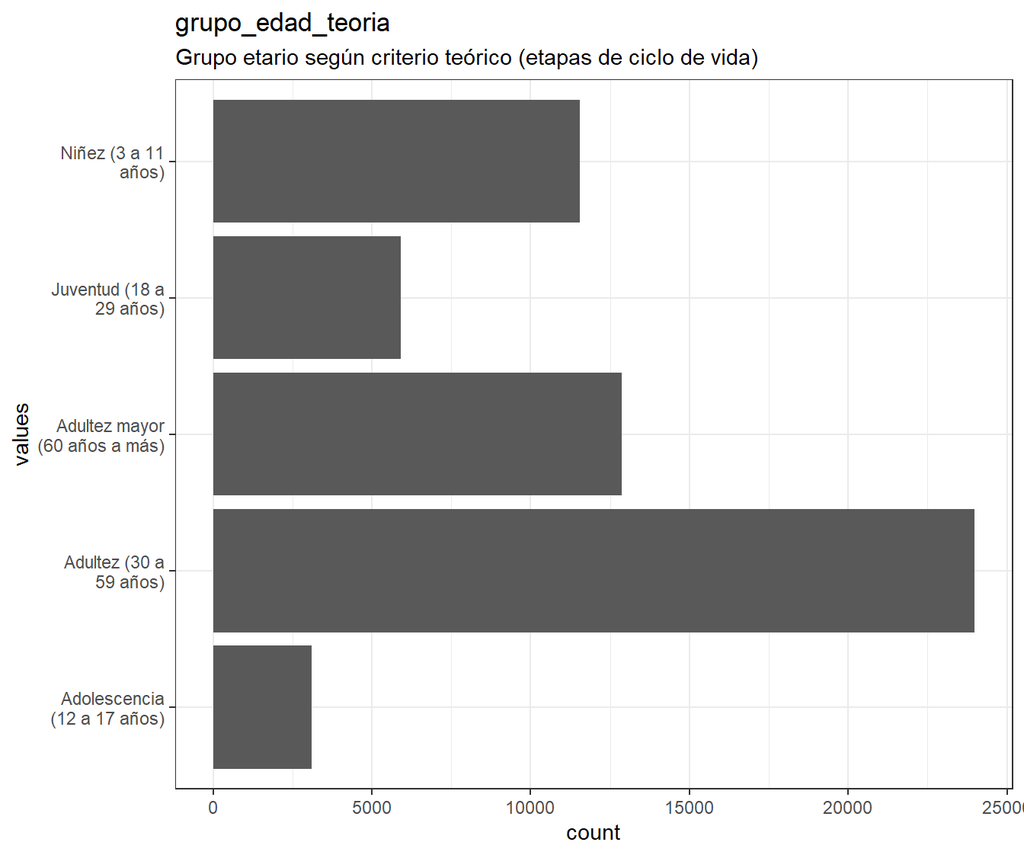

Distribution of values for grupo_edad_teoria

0 missing values.

#### Summary statistics

| name | label | data_type | ordered | value_labels | n_missing | complete_rate | n_unique | top_counts | description |
| --- | --- | --- | --- | --- | --- | --- | --- | --- | --- |
| grupo_edad_teoria | Grupo etario según criterio teórico (etapas de ciclo de vida) | factor | FALSE | 1. Adolescencia (12 a 17 años), 2. Adultez (30 a 59 años), 3. Adultez mayor (60 años a más), 4. Juventud (18 a 29 años), 5. Niñez (3 a 11 años) | 0 | 1 | 5 | Adu: 23975, Adu: 12876, Niñ: 11560, Juv: 5911 | Grupos etarios definidos por ciclo de vida: Niñez (3-11 años), Adolescencia (12-17), Juventud (18-29), Adultez (30-59), Adultez mayor (60 a más). |

### nivel_edu_agrupado

Nivel educativo agrupado en 7 categorías

#### Distribution

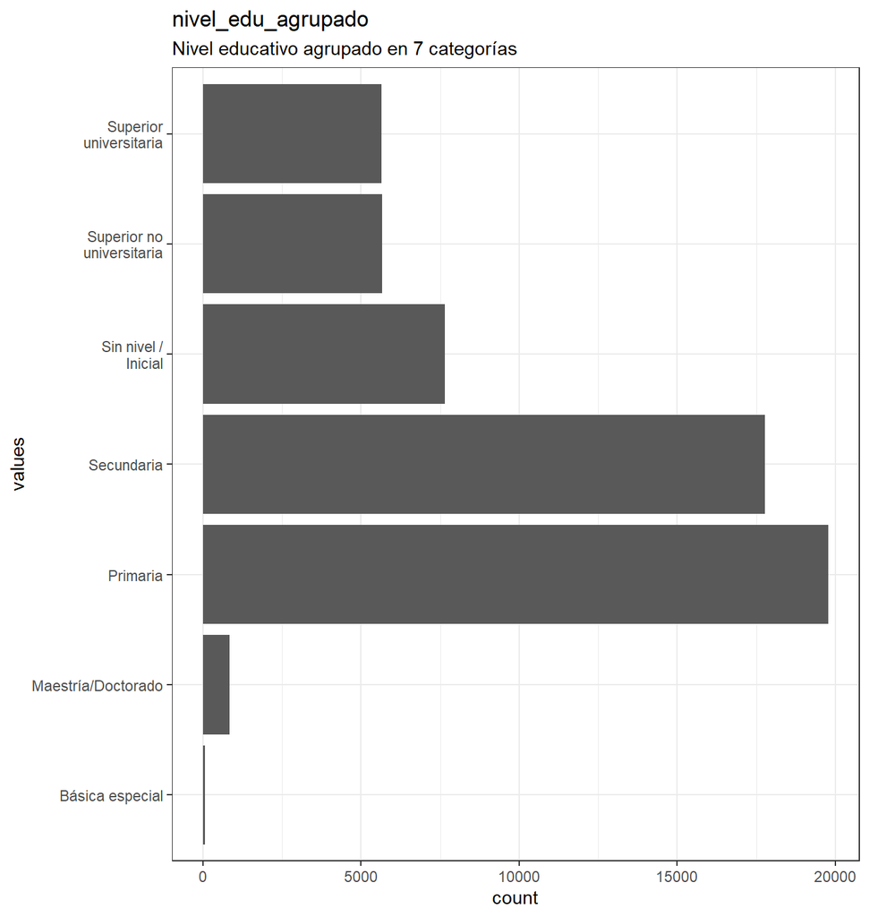

Distribution of values for nivel_edu_agrupado

0 missing values.

#### Summary statistics

| name | label | data_type | ordered | value_labels | n_missing | complete_rate | n_unique | top_counts | description |
| --- | --- | --- | --- | --- | --- | --- | --- | --- | --- |
| nivel_edu_agrupado | Nivel educativo agrupado en 7 categorías | factor | FALSE | 1. Básica especial, 2. Maestría/Doctorado, 3. Primaria, 4. Secundaria, 5. Sin nivel / Inicial, 6. Superior no universitaria, 7. Superior universitaria | 0 | 1 | 7 | Pri: 19768, Sec: 17782, Sin: 7645, Sup: 5673 | Agrupación de las 12 categorías originales de P301A en 7 niveles: Sin nivel/Inicial, Primaria, Secundaria, Superior no universitaria, Superior universitaria, Maestría/Doctorado, Básica especial. |

### grupo_edad_datos

Grupo etario según criterio de datos (terciles de la distribución empírica de edad)

#### Distribution

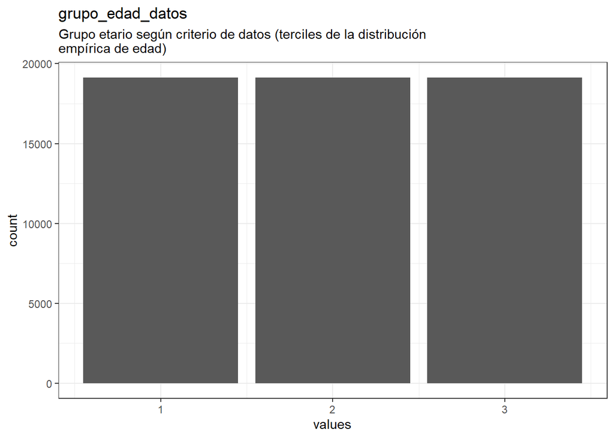

Distribution of values for grupo_edad_datos

0 missing values.

#### Summary statistics

| name | label | data_type | n_missing | complete_rate | min | median | max | mean | sd | hist | description |
| --- | --- | --- | --- | --- | --- | --- | --- | --- | --- | --- | --- |
| grupo_edad_datos | Grupo etario según criterio de datos (terciles de la distribución empírica de edad) | numeric | 0 | 1 | 1 | 2 | 3 | 1.999983 | 0.8165001 | ▇▁▇▁▇ | Terciles de edad, calculados sobre la distribución empírica de la muestra, como criterio alternativo al grupo_edad_teoria. Se incluye ello como una segunda forma de agrupar por edad, para comprobar si… |

## Codebook table

| name | label | data_type | ordered | value_labels | n_missing | complete_rate | n_unique | top_counts | min | median | max | mean | sd | hist | description |
| --- | --- | --- | --- | --- | --- | --- | --- | --- | --- | --- | --- | --- | --- | --- | --- |
| edad | Edad del encuestado, en años cumplidos (Fuente: P208A) | numeric | NA | NA | 0 | 1 | NA | NA | 3.0 | 40.0 | 98.0 | 39.334802 | 23.3931831 | ▇▆▇▅▁ | NA |
| sexo | Sexo del encuestado (Fuente: P207) | factor | FALSE | 1. Hombre, 2. Mujer | 0 | 1 | 2 | Muj: 33302, Hom: 24120 | NA | NA | NA | NA | NA | NA | NA |
| nivel_edu_etiqueta | Nivel educativo alcanzado, 12 categorías originales (Fuente: P301A) | factor | FALSE | 1. Sin nivel, 2. Educación inicial, 3. Primaria incompleta, 4. Primaria completa, 5. Secundaria incompleta, 6. Secundaria completa, 7. Superior no universitaria incompleta, 8. Superior no universitari… | 0 | 1 | 12 | Pri: 13471, Sec: 11373, Sec: 6409, Pri: 6297 | NA | NA | NA | NA | NA | NA | Se eliminaron los casos con código 99 (No especificado, MCAR) antes de exportar la base acondicionada (script 02). |
| matricula_anterior_etiqueta | ¿Estuvo matriculado en algún centro o programa educativo el año pasado? (Fuente: P303) | factor | FALSE | 1. Sí, 2. No | 0 | 1 | 2 | No: 42220, Sí: 15202 | NA | NA | NA | NA | NA | NA | NA |
| ia_preocupacion_etiqueta | Preocupación por falta de comida en el hogar (Fuente: P130_1) | factor | FALSE | 1. Sí, 2. No | 0 | 1 | 2 | No: 28938, Sí: 28484 | NA | NA | NA | NA | NA | NA | Las 8 preguntas FIES presentan NA estructural (45% de los casos, hogares donde no se aplicó el módulo 130 ese mes); estos casos se eliminaron. Las respuestas ‘No sabe’/‘No responde’ se recodificaron c… |
| ia_no_saludable_etiqueta | No comió alimentos saludables/nutritivos (Fuente: P130_2) | factor | FALSE | 1. Sí, 2. No | 0 | 1 | 2 | No: 33479, Sí: 23943 | NA | NA | NA | NA | NA | NA | NA |
| ia_no_variado_etiqueta | No comió alimentos variados (Fuente: P130_3) | factor | FALSE | 1. Sí, 2. No | 0 | 1 | 2 | No: 34967, Sí: 22455 | NA | NA | NA | NA | NA | NA | NA |
| ia_saltó_comida_etiqueta | Dejó de desayunar, almorzar o cenar (Fuente: P130_4) | factor | FALSE | 1. Sí, 2. No | 0 | 1 | 2 | No: 47318, Sí: 10104 | NA | NA | NA | NA | NA | NA | NA |
| ia_comió_menos_etiqueta | Comió menor cantidad de lo normal (Fuente: P130_5) | factor | FALSE | 1. Sí, 2. No | 0 | 1 | 2 | No: 41101, Sí: 16321 | NA | NA | NA | NA | NA | NA | NA |
| ia_sin_alimentos_etiqueta | El hogar se quedó sin alimentos (Fuente: P130_6) | factor | FALSE | 1. Sí, 2. No | 0 | 1 | 2 | No: 50122, Sí: 7300 | NA | NA | NA | NA | NA | NA | NA |
| ia_hambre_etiqueta | Tuvo hambre pero no comió (Fuente: P130_7) | factor | FALSE | 1. Sí, 2. No | 0 | 1 | 2 | No: 50597, Sí: 6825 | NA | NA | NA | NA | NA | NA | NA |
| ia_dia_sin_comer_etiqueta | Estuvo sin comer un día entero (Fuente: P130_8) | factor | FALSE | 1. Sí, 2. No | 0 | 1 | 2 | No: 54680, Sí: 2742 | NA | NA | NA | NA | NA | NA | NA |
| score_fies_bruto | Puntaje bruto FIES: N° de respuestas afirmativas (0 a 8) | numeric | NA | NA | 0 | 1 | NA | NA | 0.0 | 1.0 | 8.0 | 2.057992 | 2.3624446 | ▇▃▁▂▁ | Suma simple de respuestas afirmativas (‘Sí’=1) a las 8 preguntas de la escala FIES (rango 0 a 8). |
| severidad_rasch | Severidad latente estimada por el modelo Rasch ponderado (RM.weights) | numeric | NA | NA | 0 | 1 | NA | NA | -4.1 | -3.2 | 4.5 | -2.015395 | 2.4855328 | ▇▃▂▁▁ | Estimado mediante un modelo Rasch ponderado (paquete RM.weights, metodología FIES/Voices of the Hungry de la FAO). El modelo genera un valor por cada puntaje bruto posible (0 a 8, 9 valores), asignado… |
| nivel_inseguridad_alimentaria | Nivel de inseguridad alimentaria (4 categorías, según puntos de corte FIES) | factor | FALSE | 1. 1. Seguridad alimentaria, 2. 2. Inseguridad leve, 3. 3. Inseguridad moderada, 4. 4. Inseguridad severa | 0 | 1 | 4 | 1. : 24615, 2. : 17970, 3. : 10833, 4. : 4004 | NA | NA | NA | NA | NA | NA | Clasificación en 4 niveles usando los puntos de corte estándar (4 y 7) para escalas FIES de 8 ítems: 0 respuestas=‘Seguridad alimentaria’, 1-3=‘Inseguridad leve’, 4-6=‘Inseguridad moderada’, 7-8=‘Inse… |
| grupo_edad_teoria | Grupo etario según criterio teórico (etapas de ciclo de vida) | factor | FALSE | 1. Adolescencia (12 a 17 años), 2. Adultez (30 a 59 años), 3. Adultez mayor (60 años a más), 4. Juventud (18 a 29 años), 5. Niñez (3 a 11 años) | 0 | 1 | 5 | Adu: 23975, Adu: 12876, Niñ: 11560, Juv: 5911 | NA | NA | NA | NA | NA | NA | Grupos etarios definidos por ciclo de vida: Niñez (3-11 años), Adolescencia (12-17), Juventud (18-29), Adultez (30-59), Adultez mayor (60 a más). |
| nivel_edu_agrupado | Nivel educativo agrupado en 7 categorías | factor | FALSE | 1. Básica especial, 2. Maestría/Doctorado, 3. Primaria, 4. Secundaria, 5. Sin nivel / Inicial, 6. Superior no universitaria, 7. Superior universitaria | 0 | 1 | 7 | Pri: 19768, Sec: 17782, Sin: 7645, Sup: 5673 | NA | NA | NA | NA | NA | NA | Agrupación de las 12 categorías originales de P301A en 7 niveles: Sin nivel/Inicial, Primaria, Secundaria, Superior no universitaria, Superior universitaria, Maestría/Doctorado, Básica especial. |
| grupo_edad_datos | Grupo etario según criterio de datos (terciles de la distribución empírica de edad) | numeric | NA | NA | 0 | 1 | NA | NA | 1.0 | 2.0 | 3.0 | 1.999983 | 0.8165001 | ▇▁▇▁▇ | Terciles de edad, calculados sobre la distribución empírica de la muestra, como criterio alternativo al grupo_edad_teoria. Se incluye ello como una segunda forma de agrupar por edad, para comprobar si… |

**JSON-LD metadata**

The following JSON-LD can be found by search engines, if you share this codebook publicly on the web.

```json
{
  "name": "Base de Datos Analítica - Inseguridad Alimentaria ENAHO 2025",
  "description": "Submuestra de la Encuesta Nacional de Hogares (2025) restringida a personas con nivel educativo declarado y cuyo hogar respondió el módulo de Inseguridad Alimentaria (módulo 130).\n\n\n## Table of variables\nThis table contains variable names, labels, and number of missing values.\nSee the complete codebook for more.\n\n|name                          |label                                                                                  | n_missing|\n|:-----------------------------|:--------------------------------------------------------------------------------------|---------:|\n|edad                          |Edad del encuestado, en años cumplidos (Fuente: P208A)                                 |         0|\n|sexo                          |Sexo del encuestado (Fuente: P207)                                                     |         0|\n|nivel_edu_etiqueta            |Nivel educativo alcanzado, 12 categorías originales (Fuente: P301A)                    |         0|\n|matricula_anterior_etiqueta   |¿Estuvo matriculado en algún centro o programa educativo el año pasado? (Fuente: P303) |         0|\n|ia_preocupacion_etiqueta      |Preocupación por falta de comida en el hogar (Fuente: P130_1)                          |         0|\n|ia_no_saludable_etiqueta      |No comió alimentos saludables/nutritivos (Fuente: P130_2)                              |         0|\n|ia_no_variado_etiqueta        |No comió alimentos variados (Fuente: P130_3)                                           |         0|\n|ia_saltó_comida_etiqueta      |Dejó de desayunar, almorzar o cenar (Fuente: P130_4)                                   |         0|\n|ia_comió_menos_etiqueta       |Comió menor cantidad de lo normal (Fuente: P130_5)                                     |         0|\n|ia_sin_alimentos_etiqueta     |El hogar se quedó sin alimentos (Fuente: P130_6)                                       |         0|\n|ia_hambre_etiqueta            |Tuvo hambre pero no comió (Fuente: P130_7)                                             |         0|\n|ia_dia_sin_comer_etiqueta     |Estuvo sin comer un día entero (Fuente: P130_8)                                        |         0|\n|score_fies_bruto              |Puntaje bruto FIES: N° de respuestas afirmativas (0 a 8)                               |         0|\n|severidad_rasch               |Severidad latente estimada por el modelo Rasch ponderado (RM.weights)                  |         0|\n|nivel_inseguridad_alimentaria |Nivel de inseguridad alimentaria (4 categorías, según puntos de corte FIES)            |         0|\n|grupo_edad_teoria             |Grupo etario según criterio teórico (etapas de ciclo de vida)                          |         0|\n|nivel_edu_agrupado            |Nivel educativo agrupado en 7 categorías                                               |         0|\n|grupo_edad_datos              |Grupo etario según criterio de datos (terciles de la distribución empírica de edad)    |         0|\n\n### Note\nThis dataset was automatically described using the [codebook R package](https://rubenarslan.github.io/codebook/) (version 0.10.1).",
  "creator": "Micaela Cusipuma",
  "datePublished": "2026-07-12",
  "keywords": ["edad", "sexo", "nivel_edu_etiqueta", "matricula_anterior_etiqueta", "ia_preocupacion_etiqueta", "ia_no_saludable_etiqueta", "ia_no_variado_etiqueta", "ia_saltó_comida_etiqueta", "ia_comió_menos_etiqueta", "ia_sin_alimentos_etiqueta", "ia_hambre_etiqueta", "ia_dia_sin_comer_etiqueta", "score_fies_bruto", "severidad_rasch", "nivel_inseguridad_alimentaria", "grupo_edad_teoria", "nivel_edu_agrupado", "grupo_edad_datos"],
  "@context": "https://schema.org/",
  "@type": "Dataset",
  "variableMeasured": [
    {
      "name": "edad",
      "description": "Edad del encuestado, en años cumplidos (Fuente: P208A)",
      "@type": "propertyValue"
    },
    {
      "name": "sexo",
      "description": "Sexo del encuestado (Fuente: P207)",
      "value": "1. Hombre,\n2. Mujer",
      "@type": "propertyValue"
    },
    {
      "description": "Nivel educativo alcanzado, 12 categorías originales (Fuente: P301A)",
      "name": "nivel_edu_etiqueta",
      "value": "1. Sin nivel,\n2. Educación inicial,\n3. Primaria incompleta,\n4. Primaria completa,\n5. Secundaria incompleta,\n6. Secundaria completa,\n7. Superior no universitaria incompleta,\n8. Superior no universitaria completa,\n9. Superior universitaria incompleta,\n10. Superior universitaria completa,\n11. Maestría/Doctorado,\n12. Básica especial",
      "@type": "propertyValue"
    },
    {
      "name": "matricula_anterior_etiqueta",
      "description": "¿Estuvo matriculado en algún centro o programa educativo el año pasado? (Fuente: P303)",
      "value": "1. Sí,\n2. No",
      "@type": "propertyValue"
    },
    {
      "description": "Preocupación por falta de comida en el hogar (Fuente: P130_1)",
      "name": "ia_preocupacion_etiqueta",
      "value": "1. Sí,\n2. No",
      "@type": "propertyValue"
    },
    {
      "name": "ia_no_saludable_etiqueta",
      "description": "No comió alimentos saludables/nutritivos (Fuente: P130_2)",
      "value": "1. Sí,\n2. No",
      "@type": "propertyValue"
    },
    {
      "name": "ia_no_variado_etiqueta",
      "description": "No comió alimentos variados (Fuente: P130_3)",
      "value": "1. Sí,\n2. No",
      "@type": "propertyValue"
    },
    {
      "name": "ia_saltó_comida_etiqueta",
      "description": "Dejó de desayunar, almorzar o cenar (Fuente: P130_4)",
      "value": "1. Sí,\n2. No",
      "@type": "propertyValue"
    },
    {
      "name": "ia_comió_menos_etiqueta",
      "description": "Comió menor cantidad de lo normal (Fuente: P130_5)",
      "value": "1. Sí,\n2. No",
      "@type": "propertyValue"
    },
    {
      "name": "ia_sin_alimentos_etiqueta",
      "description": "El hogar se quedó sin alimentos (Fuente: P130_6)",
      "value": "1. Sí,\n2. No",
      "@type": "propertyValue"
    },
    {
      "name": "ia_hambre_etiqueta",
      "description": "Tuvo hambre pero no comió (Fuente: P130_7)",
      "value": "1. Sí,\n2. No",
      "@type": "propertyValue"
    },
    {
      "name": "ia_dia_sin_comer_etiqueta",
      "description": "Estuvo sin comer un día entero (Fuente: P130_8)",
      "value": "1. Sí,\n2. No",
      "@type": "propertyValue"
    },
    {
      "description": "Puntaje bruto FIES: N° de respuestas afirmativas (0 a 8)",
      "name": "score_fies_bruto",
      "@type": "propertyValue"
    },
    {
      "description": "Severidad latente estimada por el modelo Rasch ponderado (RM.weights)",
      "name": "severidad_rasch",
      "@type": "propertyValue"
    },
    {
      "description": "Nivel de inseguridad alimentaria (4 categorías, según puntos de corte FIES)",
      "name": "nivel_inseguridad_alimentaria",
      "value": "1. 1. Seguridad alimentaria,\n2. 2. Inseguridad leve,\n3. 3. Inseguridad moderada,\n4. 4. Inseguridad severa",
      "@type": "propertyValue"
    },
    {
      "description": "Grupo etario según criterio teórico (etapas de ciclo de vida)",
      "name": "grupo_edad_teoria",
      "value": "1. Adolescencia (12 a 17 años),\n2. Adultez (30 a 59 años),\n3. Adultez mayor (60 años a más),\n4. Juventud (18 a 29 años),\n5. Niñez (3 a 11 años)",
      "@type": "propertyValue"
    },
    {
      "description": "Nivel educativo agrupado en 7 categorías",
      "name": "nivel_edu_agrupado",
      "value": "1. Básica especial,\n2. Maestría/Doctorado,\n3. Primaria,\n4. Secundaria,\n5. Sin nivel / Inicial,\n6. Superior no universitaria,\n7. Superior universitaria",
      "@type": "propertyValue"
    },
    {
      "description": "Grupo etario según criterio de datos (terciles de la distribución empírica de edad)",
      "name": "grupo_edad_datos",
      "@type": "propertyValue"
    }
  ]
}`
```